# Best of the Decade

Julianna Calabrese

December 16, 2019

# Introduction

Since the decade is ending, [my lab members and I](https://sites.lsa.umich.edu/monk-lab/senior-staff/) decided to vote on the best entertainment of the decade. We agreed that it was a good idea to 1) teach our undergraduate research assistants about data collection and visualization, and 2) judge each other’s pop culture opinions.

# Methods

Nominations were chosen by huddling around a whiteboard and writing down ideas as we came up with them. Individuals who happened to be around the office and walking down the hallway were encouraged to write down their favorites of the decade. People could nominate their choices for a work week (November 11 to November 15). After nominations finished, a Qualtrics survey was created and informally shared with individuals. A shortened URL to the Qualtrics link was also posted on the door outside the office with the whiteboard. The Qualtrics survey was closed on December 1.

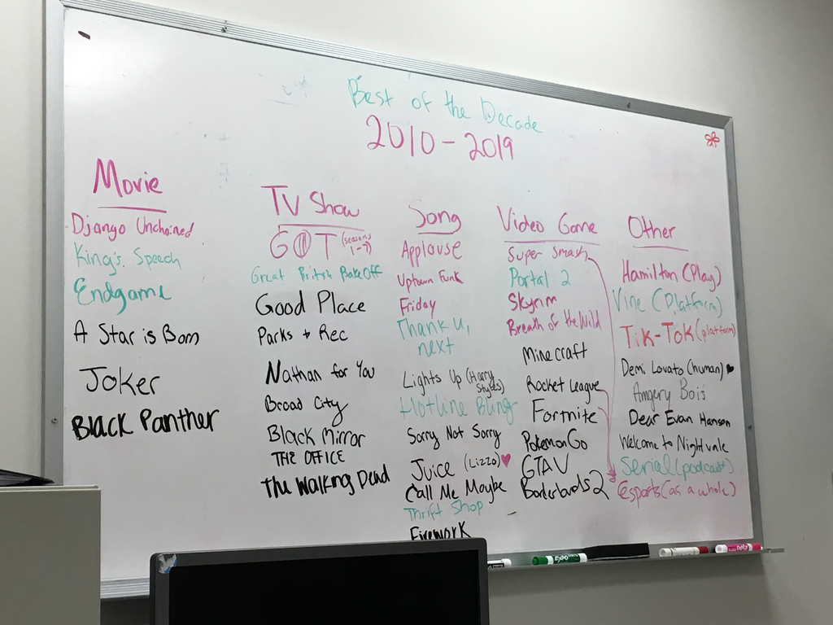

There were five total questions: Best Movie, Best TV Show, Best Song, Best Video Game, and Best Other. “Other” entertainment include theater productions, podcasts, and social media platforms. Please see the lists below for specific nominations.

For each of the five categories, there was an extra option that said “I don’t know enough about these movies/TV shows/etc. to decide” in case responders didn’t recognize the nominations. This “I don’t know” is represented as “NA” in below visualizations.

No demographic data was collected from responders, although the survey was advertised to individuals in an academic building. Responders are likely majority female and are between 18 and 29 years old.

During the nomination process, we defined the past decade as between 2010 and 2019. Entertainment produced in 2009 was deemed ineligible. After lengthy discussions, we decided to exclude The Office (2005 - 2013) and Grey’s Anatomy (2005 - Present) from the nominations. Although there was content produced by these TV shows between 2009 and 2019, the lab members and I unanimously agreed that content from these shows produced after 2009 was not very good and therefore these shows should not be included among the nominations. We also agreed to exclude humans (e.g. Demi Lovato) and general pop culture phenomena (e.g. eSports) from the Other category, as well as exclude trends and newly-created genres (e.g. SoundCloud rappers, generic YouTube EDM) from the Song category.

# Nominations

## Movies

- A Star Is Born (2018)
- Avengers: Endgame (2019)
- Black Panther (2018)
- Dark Knight Rises (2012)
- Django Unchained (2012)
- Get Out (2017)
- Inception (2010)
- Joker (2019)
- The King’s Speech (2010)
- The Social Network (2010)
- Theory of Everything (2014)

## TV Shows

- Black Mirror (2011 - Present)
- Broad City (2014 - 2019)
- Game of Thrones (2011 - 2019)
- Great British Bake Off (2010 - Present)
- Nathan for You (2013 - 2018)
- Parks and Recreation (2009 -2015)
- Sherlock (2010 - 2017)
- Stranger Things (2016 - Present)
- The Good Place (2016 - Present)
- The Walking Dead (2010 - Present)

## Video Games

- Fortnite (2017)
- Grand Theft Auto V (2013)
- Legend of Zelda: Breath of the Wild (2017)
- Minecraft (2011)
- Pokémon GO (2016)
- Portal 2 (2011)
- Rocket League (2015)
- Super Mario Odyssey (2017)
- Super Smash Bros. Ultimate (2018)
- The Elder Scrolls V: Skyrim (2012)
- Undertale (2015)

# Results

The Qualtrics survey received 22 responses. One response was removed due to incomplete data, resulting in a total of 21 usable responses.

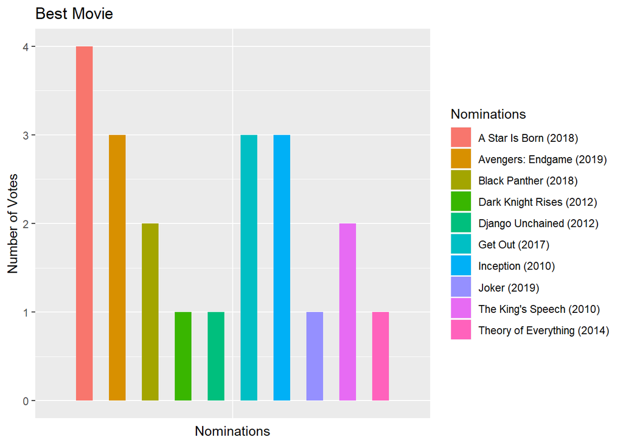

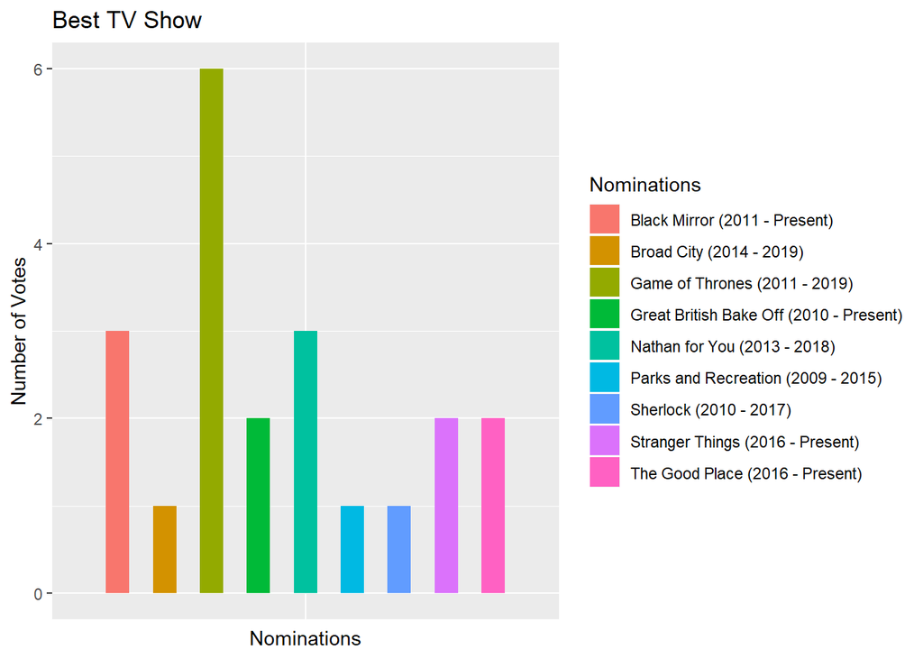

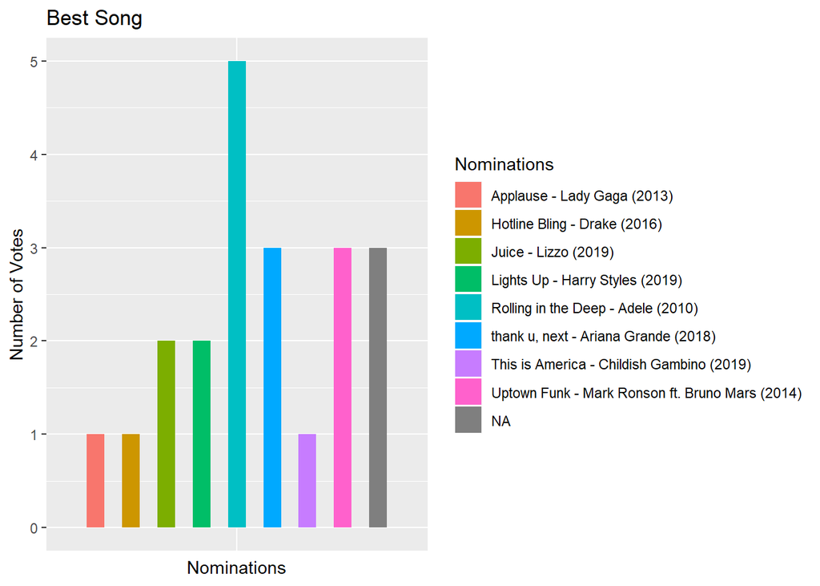

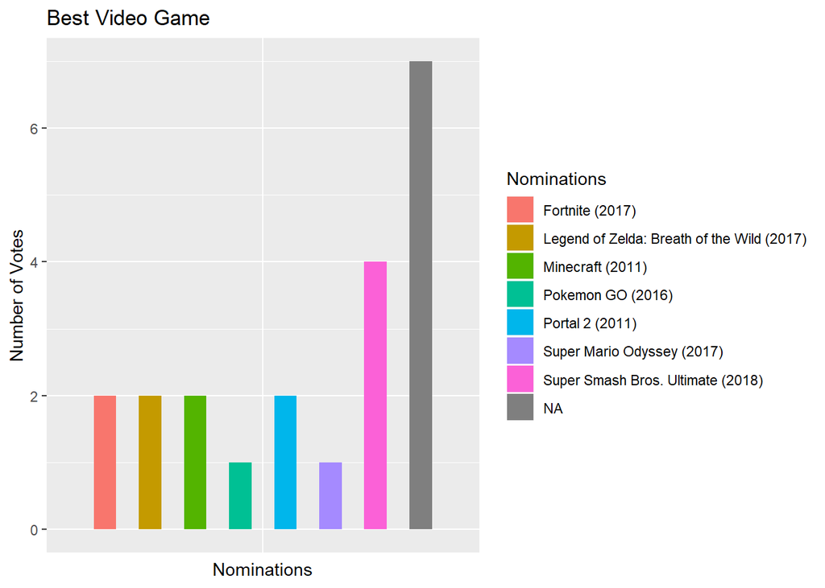

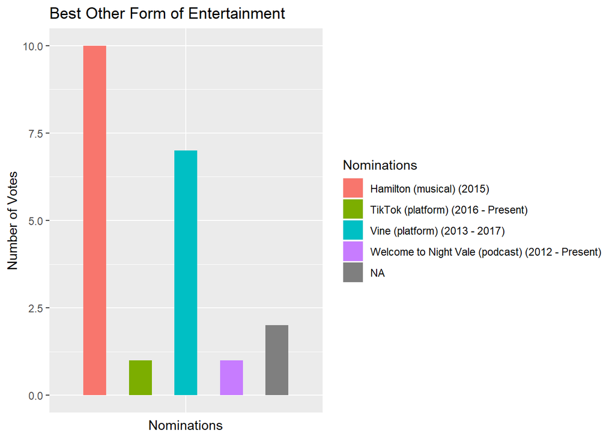

# Discussion

The Movie category was the most hotly-contested category. A Star Is Born (2018) won by only one vote, beating out Avengers: Endgame (2019), Get Out (2017), and Inception (2010). It is important to note that the 2018 version of A Star Is Born is a remake of a remake of a remake, following versions produced in 1937, 1954, and 1976.

Game of Thrones (2011 - 2019) won TV Show category by a landslide, only followed by Black Mirror (2011 - Present) and Nathan for You (2013 - 2018). Although no one can doubt the impact of Game of Thrones on the decade as a whole, responders thoroughly agreed that the last two seasons were lackluster.

Surprisingly, Adele’s Rolling in the Deep (2010) won the Song category, followed by thank, u next by Ariana Grande (2018) and Uptown Funk by Mark Ronson ft. Bruno Mars (2014). Rolling in the Deep was a last-minute addition to the nomination list and while Adele’s first comeback album may not have been extremely impactful on the decade as a whole, it is difficult to ignore her authoritative vocal skills.

Unfortunately, “I don’t know” clearly won the video game category. This was an extremely disappointing result to the survey creator. In discussions with responders after the results were in, many communicated that they had little experience with video games in the past decade. Most had experience with games released on Nintendo’s Wii (2007) with many of its most popular games being released before 2009 (e.g. Mario Kart Wii in 2008). In a far second, Super Smash Bros Ultimate (2018) had four votes. While the survey creator disagrees with this opinion, Super Smash Bros Ultimate had sold [over 15 million copies as of September 2019](https://www.forbes.com/sites/erikkain/2020/01/02/the-nintendo-switch-has-now-sold-more-units-than-the-super-nes/#6cc64d6646cd) and is the second top-selling video game for the Nintendo Switch.

# Conclusion

In conclusion, the 2010s were extremely entertaining. While the Movie and Video Game results were disappointing, the survey creator aims to teach undergraduates about how this data was collected and visualized using ggplot2, as well as teach them about the superiority of Valve’s Portal 2 (2011) video game.